# Exploratory Data Analysis and Descriptive Statistics with R

Mitch Harden

March 12, 2016

Analysis and Report were generated using R version 3.2.4 (2016-03-10) and KNITR via RStudio.

Load R libraries

```r
library(foreign)
library(ggplot2)
library(moments)
```

Data acquired from source, uncompressed, and read into R:

```r
setwd("~/Maryville/EDL735")
download.file("http://spss5.allenandunwin.com.s3-website-ap-southeast-2.amazonaws.com/Files/sleep5ED.zip",dest="sleep5ED.zip", mode="wb")
unzip("sleep5ED.zip")
sleep5ed = read.spss("sleep5ED/sleep5ED.sav", to.data.frame=TRUE)
attach(sleep5ed)
```

# 1. Generate appropriate descriptive statistics to answer the following:

## 1.1 What percentage of respondents are female? (sex)

```r
prop.table(table(sex))
```

```
## sex
##    female      male
## 0.5535055 0.4464945
```

**Interpretation**

55.35% of participants were female.

## 1.2 What is the average age of the sample? (age)

```r
summary(age)
```

```
##    Min. 1st Qu.  Median    Mean 3rd Qu.    Max.    NA's
##   18.00   34.00   44.00   43.87   54.00   84.00      23
```

**Interpretation**

The average age of participants was 43.87 years

## 1.3 What is the percentage of the samle indicated that they had a prolem with their sleep (probsleeprec)

```r
prop.table(table(probsleeprec))
```

```
## probsleeprec
##        no       yes
## 0.5650558 0.4349442
```

**Interpretation**

43.49% of participants reported problems with their sleep.

## 1.4 What is the median number of hours sleep per weeknight? (hourwnit)

```r
summary(hourwnit)
```

```
##    Min. 1st Qu.  Median    Mean 3rd Qu.    Max.    NA's
##   3.000   6.000   7.000   6.972   8.000  10.000       1
```

**Interpretation**

Participants slept a median of 7 hours on week nights.

# 2. Assess the distribution of scores on the Sleepiness and Associated Sensations Scale (toSAS) for people who feel thatthey do/don’t have a sleep problem (probsleeprec).

```r
detach(sleep5ed)
# Subset the Data by Sleep Problems
sleep5edclean <- subset(sleep5ed,!(is.na(sleep5ed$totsas)))
noprobs <- subset(sleep5edclean, probsleeprec=="no")
yesprobs <- subset(sleep5edclean, probsleeprec=="yes")
nptotsas <- data.frame(noprobs$totsas)
yptotsas <- data.frame(yesprobs$totsas)
```

## 2.1 Are there any Outliers on this scale that you would be concerned about?

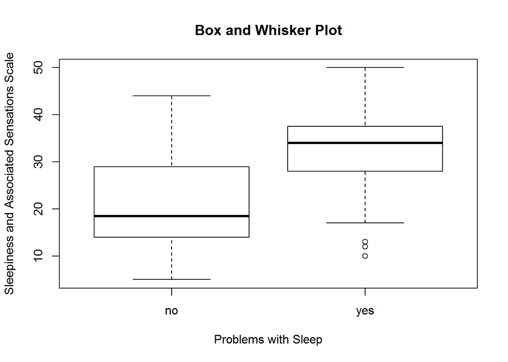

```r
boxplot(totsas ~ probsleeprec, data= sleep5edclean,
        xlab= "Problems with Sleep", ylab = "Sleepiness and Associated Sensations Scale",
        main = "Box and Whisker Plot")
```

**Interpretation**

## 2.2 Are scores normally distributed for each group?

```r
#Skewness and Kurtosis
skewness(noprobs$totsas, na.rm=TRUE)
```

```
## [1] 0.4878863
```

```r
kurtosis(noprobs$totsas, na.rm=TRUE) -3
```

```
## [1] -0.8056236
```

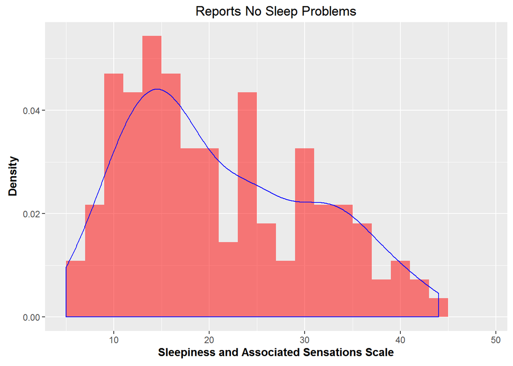

```r
#Histogram for NoSleep Problems
ggplot(data.frame(nptotsas), aes(x = noprobs$totsas)) +
  geom_histogram(aes(y = ..density..), breaks=seq(5, 50, by = 2), fill = 'red', alpha = 0.5) +
  geom_density(colour = 'blue') + xlab(expression(bold('Sleepiness and Associated Sensations Scale'))) +
  ylab(expression(bold('Density'))) +
  ggtitle("Reports No Sleep Problems")
```

**Interpretation**

```r
#Skewness and Kurtosis
skewness(yesprobs$totsas, na.rm=TRUE)
```

```
## [1] -0.6344499
```

```r
kurtosis(yesprobs$totsas, na.rm=TRUE) -3
```

```
## [1] 0.08912234
```

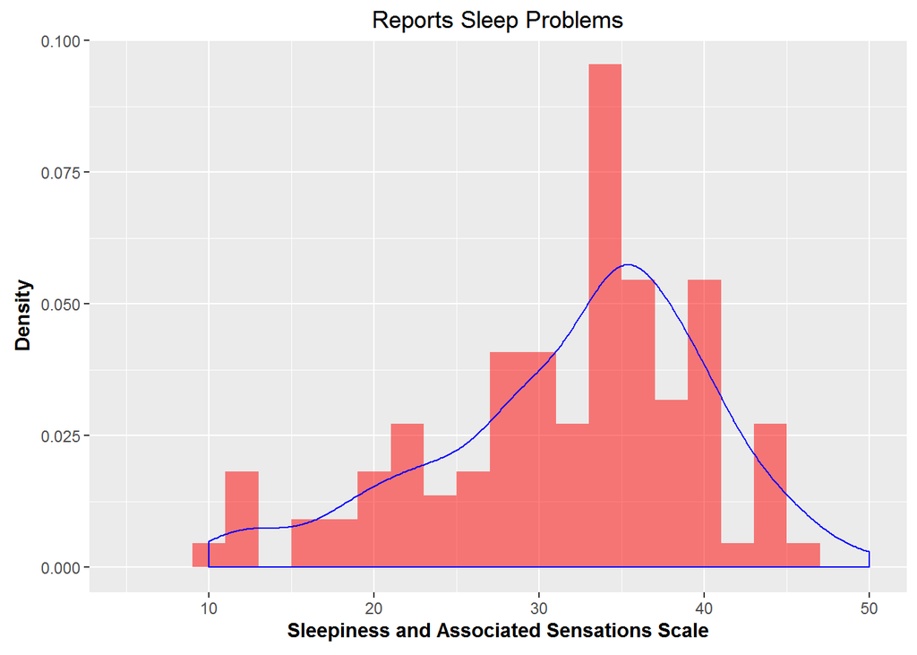

```r
#Histogram for Yes Sleep Problems
ggplot(data.frame(yptotsas), aes(x = yesprobs$totsas)) +
  geom_histogram(aes(y = ..density..), breaks=seq(5, 50, by = 2), fill = 'red', alpha = 0.5) +
  geom_density(colour = 'blue') +
  xlab(expression(bold('Sleepiness and Associated Sensations Scale'))) +
  ylab(expression(bold('Density'))) +
  ggtitle("Reports Sleep Problems")
```

**Interpretation**

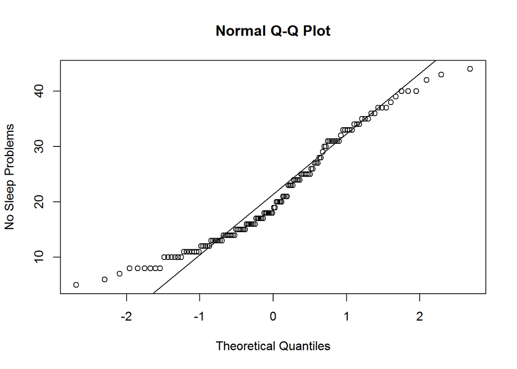

```r
#Generate Q-Q plots
qqnorm(noprobs$totsas, ylab = "No Sleep Problems") ; qqline(noprobs$totsas)
```

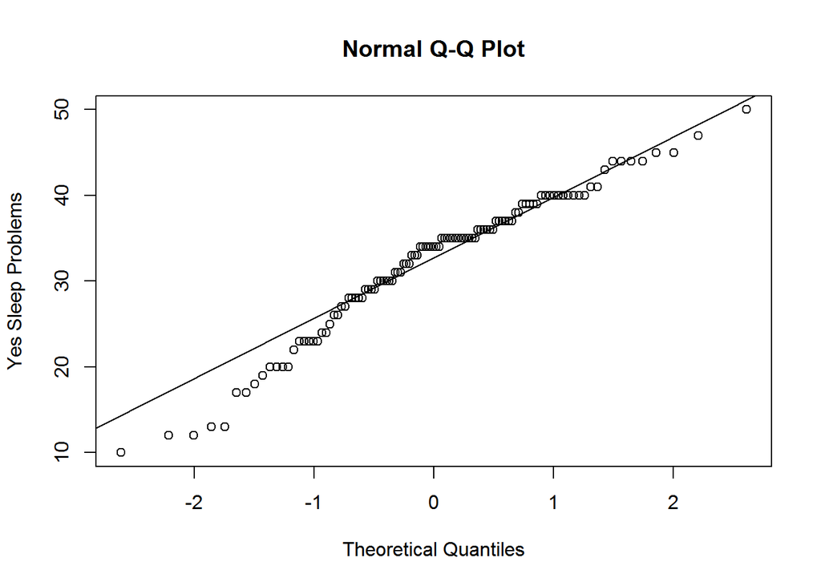

```r
qqnorm(yesprobs$totsas, ylab = "Yes Sleep Problems") ; qqline(yesprobs$totsas)
```

**Interpretation**

The Q-Q Plots for both groups depict a fairly normal distribution with a light amount of tailing, particularly in among the people reporting sleep problems.